# Deconvolving with SiNMFiD

In this vignette, we’ll be walking through some of the core functionality of the `SiNMFiD` package, as implemented for “Mesoscale Properties of Molecular Cell Types in the Mouse Brain” by Kriebel et al. (2024). First, let’s install the package from Github.

```r
devtools::install_github("welch-lab/SiNMFiD")
```

Let’s set some of the basic parameters for our analysis, namely the directory in which we’d like to build our analysis, a name to identify it by (here, corresponding to a brain region of interest), and a spatial modality to associate with it. `SiNMFiD` also allows for labeling of replicate analyses by their associated random seed.

```r
library(SiNMFiD)
filepath = "sinmfid"
analysis_name = "MOp"
spatial_data_name = "ISH"
rand_seed = 123
```

## Starting an analysis

With this information, we can initiate an analysis. `start_analysis` constructs the root of the directory structure that will store derived data and results.

```r
start_analysis(filepath, analysis_name)
```

```
#> Created directory at sinmfid/MOp
```

To add a spatial modality to the analysis, we call `save_spatial_data`. It requires filepaths for the expression data and coordinates in addition to identifying information for the analysis. In this vignette, we will be working with quantified in situ hybridization data from the Allen Brain Atlas.

```r
save_spatial_data(filepath,
                  analysis_name,
                  "sinmfid/exp.RDS",
                  "sinmfid/coords.RDS",
                  spatial_data_name)
```

```
#> Created directory at sinmfid/MOp/ISH
#> [1] TRUE
```

## Manipulating spatial data

`SiNMFiD` provides several tools for manipulating spatial data before it is deconvolved. To assess what we’re working with, we can call the `reference_3d_coordinates` function to plot silhouettes of the region volume on three perpendicular planes.

```
#> Plots generated
```

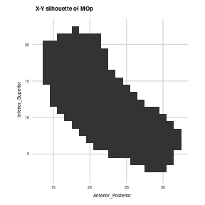

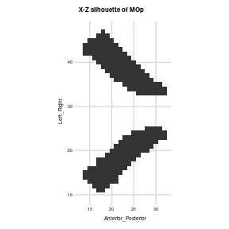

```
#> Created directory at sinmfid/MOp/ISH/plots
#> Plots saved
```

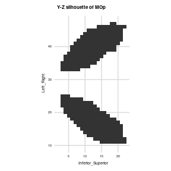

```r
reference_3d_coordinates(filepath,
                         analysis_name,
                         spatial_data_name,
                         save.plots = T)
```

We notice that the scaling of the coordinates is not similar to what is expected for data in the Allen Common Coordinate framework, a standard in neuroscience research. Luckily, we have a helper function `transform_coords_to_ccf` written to scale and shift our specific data to align. This creates a new spatial modality, named after our original with `_ccf` appended.

```r
transform_coords_to_ccf(filepath,
                        analysis_name,
                        spatial_data_name)
```

```
#> Created directory at sinmfid/MOp/ISH_ccf
#> [1] TRUE
```

We know that only one of the hemispheres of the brain is densely covered in the quantified ISH dataset. We can use the `subset_spatial_data` to create an object with only those samples. Understanding the `subset_specs` parameter of `subset_spatial_data` function is essential for proper usage. The elements of the list correspond to sequential axes in the data, with the first element of those vectors corresponding to the lower bound and the second to the upper bound, where `NaN` implies there is not a limit. This function also creates a new spatial modality, here appended from our previous with `_subset_` followed by the number of samples included after subsetting.

```r
spatial_data_name = "ISH_ccf"
subset_spatial_data(filepath,
                    analysis_name,
                    spatial_data_name,
                    subset.specs = list(c(NaN,NaN),
                         c(NaN,NaN),
                         c(8000,NaN)))
```

```
#> Sample subset to 927 samples.
#> Created directory at sinmfid/MOp/ISH_ccf_subset_927
#> Saved expression and coordinates to sinmfid/MOp/ISH_ccf_subset_927
```

Let’s check out the silhouttes again to confirm that our operations were successful.

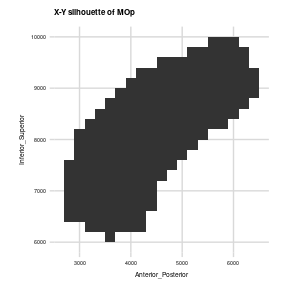

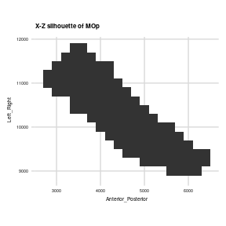

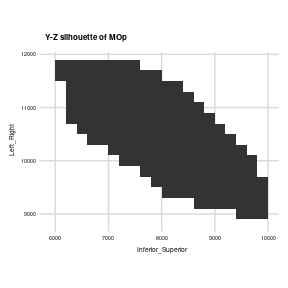

```r
spatial_data_name= "ISH_ccf_subset_927"
reference_3d_coordinates(filepath,
                         analysis_name,
                         spatial_data_name,
                         save.plots = T)
```

## Preparing reference data

Before we can deconvolve our spatial data, we will need to process our references. Here, I will be providing a vector of H5 files as input, though `rliger` objects and lists of sparse matrices are also valid as input. I will also be supplying annotations generated for the aformentioned publication.

```r
data_path = "MOp"
data = file.path(data_path,c("Analysis2_MOp/MOp_sc10Xv2_qc.H5",
                           "Analysis2_MOp/MOp_sc10Xv3_qc.H5",
                           "Analysis2_MOp/MOp_sn10Xv3_qc.H5",
                           "Analysis4_MOp/MOp_sc10Xv2_qc.H5",
                           "Analysis4_MOp/MOp_sc10Xv3_qc.H5",
                           "Analysis4_MOp/MOp_sn10Xv3_qc.H5",
                           "Analysis4_MOp/MOp_smartseq_qc.H5",
                           "Analysis5_MOp/MOp_sc10Xv2_qc.H5",
                           "Analysis5_MOp/MOp_sc10Xv3_qc.H5",
                           "Analysis5_MOp/MOp_sn10Xv3_qc.H5",
                           "Analysis5_MOp/MOp_smartseq_qc.H5"))

annotations = readRDS(file.path(filepath,"/clusters.RDS"))
```

First, we have to downsample our data to get equal coverage of cell types with `sample_single_cell`. The most important parameter is `n.cells`. Too high of a value will result in poor identification of rare cell types and slow calculation whereas too low will not allow for accurate calculation of cell type features.

```r
sample_single_cell(data,
                   annotations,
                   filepath,
                   analysis_name,
                   n.cells = 500,
                   rand.seed = rand_seed)
```

```
#> Loading Data
#> Sampling from clusters
#> Sample summary --
#>
#>            Astro             Car3             Endo              IOL
#>              500              500              500              500
#>          L2/3 IT          L4/5 IT            L5 ET            L5 IT
#>              500              500              500              500
#>            L5 NP            L5 PT            L6 CT            L6 IT
#>              500              500              500              500
#>              L6b            Lamp5            Macro            Micro
#>              500              500              358              500
#>            Oligo              OPC            Pvalb Pvalb_Chandelier
#>              500              500              500              182
#>         SMC-Peri             Sncg              Sst        Sst_Chodl
#>              500              500              500              500
#>              Vip             VLMC             VPIA
#>              500              500              500
#> Created directory at sinmfid/MOp/123
#> Reading subsample from H5 dataset:
#>
#> Reading subsample from H5 dataset:
#>
#> Reading subsample from H5 dataset:
#>
#> Reading subsample from H5 dataset:
#>
#> Reading subsample from H5 dataset:
#>
#> Reading subsample from H5 dataset:
#>
#> Reading subsample from H5 dataset:
#>
#> Reading subsample from H5 dataset:
#>
#> Reading subsample from H5 dataset:
#>
#> Reading subsample from H5 dataset:
#>
#> Reading subsample from H5 dataset:
#>
```

We should also run `calculate_cell_sizes` to estimate the expected number of reads by cell type, important for correction of expected cell type proportions later on. There is also an optional `plot.hist` parameter which generates histograms of reads for each type as a pdf. This is the last step which references the original data.

```r
calculate_cell_sizes(data, annotations,
                     filepath,
                     analysis_name)
```

```
#> Counting for HDF5 data at: /nfs/turbo/umms-welchjd/BRAIN_initiative/Final_integration_workflow/Analyses/MOp/Analysis2_MOp/MOp_sc10Xv2_qc.H5
#>
#> Counting for HDF5 data at: /nfs/turbo/umms-welchjd/BRAIN_initiative/Final_integration_workflow/Analyses/MOp/Analysis2_MOp/MOp_sc10Xv3_qc.H5
#>
#> Counting for HDF5 data at: /nfs/turbo/umms-welchjd/BRAIN_initiative/Final_integration_workflow/Analyses/MOp/Analysis2_MOp/MOp_sn10Xv3_qc.H5
#>
#> Counting for HDF5 data at: /nfs/turbo/umms-welchjd/BRAIN_initiative/Final_integration_workflow/Analyses/MOp/Analysis4_MOp/MOp_sc10Xv2_qc.H5
#>
#> Counting for HDF5 data at: /nfs/turbo/umms-welchjd/BRAIN_initiative/Final_integration_workflow/Analyses/MOp/Analysis4_MOp/MOp_sc10Xv3_qc.H5
#>
#> Counting for HDF5 data at: /nfs/turbo/umms-welchjd/BRAIN_initiative/Final_integration_workflow/Analyses/MOp/Analysis4_MOp/MOp_sn10Xv3_qc.H5
#>
#> Counting for HDF5 data at: /nfs/turbo/umms-welchjd/BRAIN_initiative/Final_integration_workflow/Analyses/MOp/Analysis4_MOp/MOp_smartseq_qc.H5
#>
#> Counting for HDF5 data at: /nfs/turbo/umms-welchjd/BRAIN_initiative/Final_integration_workflow/Analyses/MOp/Analysis5_MOp/MOp_sc10Xv2_qc.H5
#>
#> Counting for HDF5 data at: /nfs/turbo/umms-welchjd/BRAIN_initiative/Final_integration_workflow/Analyses/MOp/Analysis5_MOp/MOp_sc10Xv3_qc.H5
#>
#> Counting for HDF5 data at: /nfs/turbo/umms-welchjd/BRAIN_initiative/Final_integration_workflow/Analyses/MOp/Analysis5_MOp/MOp_sn10Xv3_qc.H5
#>
#> Counting for HDF5 data at: /nfs/turbo/umms-welchjd/BRAIN_initiative/Final_integration_workflow/Analyses/MOp/Analysis5_MOp/MOp_smartseq_qc.H5
#>
```

From here, we can select variable genes with the Kruskal Wallis test. The most important parameter here is `deconv.gene.num`, controlling the number of genes to use downstream. It is ideal to get a set of genes that is both robust but also primarily represents variation in expression between cell types.

```r
select_defining_genes(filepath,
                      analysis_name,
                      deconv.gene.num = 1000,
                      gene.num.tol = 10,
                      rand.seed = rand_seed)
```

```
#> Selecting genes with the KW test
#> 1009 genes found with p = 0.65625
```

```r
qc_spatial_data(filepath,
                analysis_name,
                spatial_data_name,
                rand.seed = rand_seed)
```

```
#> 16184 genes saved out of 18614 total.
#> Created directory at sinmfid/MOp/ISH_ccf_subset_927/123
```